# Final project - A+ team

Chu-Chun Ku, Yi-Ting Lee, Hsiang Lee

# Case Overview

#### The challenge we faced was that Cook County, Illinois, previously used outdated SPSS technology to assess property values, which lacked transparency and accuracy. Our goal is to transition to using R for property value predictions and to develop an effective predictive model that minimizes Mean Squared Error (MSE). This process is designed to be open and transparent, fostering public trust. Using historical property data, we aim to build the model to predict residential property values in Cook County and estimate market values for 10,000 properties, ensuring fair and accurate assessments.

# Time Use

#### 10 mins

# Install tools

### Purpose:

#### Load necessary libraries for data manipulation (tidyverse), visualization (ggplot2), random forest modeling (randomForest), and hyperparameter tuning (caret).

```r
library(tidyverse)
```

```r
library(ggplot2)
library(randomForest)
library(caret)
```

# Import data and clean data

### Purpose:

#### - Load the dataset (historic_property_data.csv) and a corresponding codebook (codebook.csv) that describes the variables.

#### - Identify relevant columns that exist in both the dataset and codebook.

#### - Filter for predictors (var_is_predictor == TRUE) and the target variable (sale_price renamed to assessed_value).

#### - Create a clean dataset (m_data) containing only relevant predictors and the target variable.

#### - Save the filtered variables for record-keeping.

```r
h_data <- read_csv("historic_property_data.csv")
nrow(h_data)
```

```
## [1] 50000
```

```r
head(h_data)
```

```
## # A tibble: 6 × 63
##   sale_price meta_class meta_town_code meta_nbhd meta_certified_est_bldg
##        <dbl>      <dbl>          <dbl>     <dbl>                   <dbl>
## 1      23000        203             12     12084                   64800
## 2      95000        211             70     70120                  126710
## 3     234900        205             12     12051                  190650
## 4     110000        203             72     72071                   73610
## 5     640000        206             38     38052                  379790
## 6     195000        203             22     22111                  353430
## # ℹ 58 more variables: meta_certified_est_land <dbl>, meta_cdu <chr>,
## #   meta_deed_type <chr>, char_hd_sf <dbl>, char_age <dbl>, char_apts <dbl>,
## #   char_ext_wall <dbl>, char_roof_cnst <dbl>, char_rooms <dbl>,
## #   char_beds <dbl>, char_bsmt <dbl>, char_bsmt_fin <dbl>, char_heat <dbl>,
## #   char_oheat <dbl>, char_air <dbl>, char_frpl <dbl>, char_attic_type <dbl>,
## #   char_fbath <dbl>, char_hbath <dbl>, char_tp_plan <dbl>, char_tp_dsgn <dbl>,
## #   char_cnst_qlty <dbl>, char_site <dbl>, char_gar1_size <dbl>, …
```

```r
colnames(h_data)
```

```
##  [1] "sale_price"                  "meta_class"
##  [3] "meta_town_code"              "meta_nbhd"
##  [5] "meta_certified_est_bldg"     "meta_certified_est_land"
##  [7] "meta_cdu"                    "meta_deed_type"
##  [9] "char_hd_sf"                  "char_age"
## [11] "char_apts"                   "char_ext_wall"
## [13] "char_roof_cnst"              "char_rooms"
## [15] "char_beds"                   "char_bsmt"
## [17] "char_bsmt_fin"               "char_heat"
## [19] "char_oheat"                  "char_air"
## [21] "char_frpl"                   "char_attic_type"
## [23] "char_fbath"                  "char_hbath"
## [25] "char_tp_plan"                "char_tp_dsgn"
## [27] "char_cnst_qlty"              "char_site"
## [29] "char_gar1_size"              "char_gar1_cnst"
```

[output cut: 17 more lines]

```r
codebook <- read.csv("codebook.csv")

# Find if variables in historic_property_data.csv exist in the codebook
relevant_columns <- intersect(names(h_data), codebook$var_name_standard)

# Filter relevant variables in the codebook
filtered_codebook <- codebook %>%
filter(var_name_standard %in% relevant_columns)

# Select columns that are suitable as predictors
predictor_columns <- filtered_codebook %>%
  filter(var_is_predictor == TRUE) %>%
  pull(var_name_standard)  # Extract variable names

# Select suitable columns as predictors from historic_property_data
m_data <- h_data %>%
  select(all_of(predictor_columns), assessed_value = sale_price)
# Replace `sale_price` as the target variable

head(m_data)
```

```
## # A tibble: 6 × 41
##   char_age char_air char_apts char_attic_fnsh char_attic_type char_beds
##      <dbl>    <dbl>     <dbl>           <dbl>           <dbl>     <dbl>
## 1       58        2        NA              NA               3         3
## 2       96        2         2              NA               3         6
## 3       65        1        NA               3               2         4
## 4       89        2        NA               3               1         3
## 5       75        1        NA              NA               3         4
## 6       99        2        NA              NA               3         3
## # ℹ 35 more variables: char_bldg_sf <dbl>, char_bsmt <dbl>,
## #   char_bsmt_fin <dbl>, char_ext_wall <dbl>, char_fbath <dbl>,
## #   char_frpl <dbl>, char_gar1_area <dbl>, char_gar1_att <dbl>,
## #   char_gar1_cnst <dbl>, char_gar1_size <dbl>, char_hbath <dbl>,
## #   char_hd_sf <dbl>, char_heat <dbl>, char_oheat <dbl>, char_porch <dbl>,
## #   char_roof_cnst <dbl>, char_rooms <dbl>, char_tp_dsgn <dbl>,
## #   char_tp_plan <dbl>, char_type_resd <dbl>, char_use <dbl>, …
```

```r
colnames(m_data)
```

```
##  [1] "char_age"                    "char_air"
##  [3] "char_apts"                   "char_attic_fnsh"
##  [5] "char_attic_type"             "char_beds"
##  [7] "char_bldg_sf"                "char_bsmt"
##  [9] "char_bsmt_fin"               "char_ext_wall"
## [11] "char_fbath"                  "char_frpl"
## [13] "char_gar1_area"              "char_gar1_att"
## [15] "char_gar1_cnst"              "char_gar1_size"
## [17] "char_hbath"                  "char_hd_sf"
## [19] "char_heat"                   "char_oheat"
## [21] "char_porch"                  "char_roof_cnst"
## [23] "char_rooms"                  "char_tp_dsgn"
## [25] "char_tp_plan"                "char_type_resd"
## [27] "char_use"                    "econ_midincome"
## [29] "econ_tax_rate"               "geo_floodplain"
## [31] "geo_ohare_noise"             "geo_withinmr100"
## [33] "geo_withinmr101300"          "ind_garage"
## [35] "meta_nbhd"                   "meta_town_code"
## [37] "geo_fs_flood_risk_direction" "geo_fs_flood_factor"
## [39] "geo_school_elem_district"    "geo_school_hs_district"
## [41] "assessed_value"
```

```r
# Save the list of filtered variables to a file
write.csv(filtered_codebook, "selected_predictor_codebook.csv", row.names = FALSE)
```

# Data Summary

### Purpose:

#### - Summarize the numeric columns by calculating their mean and standard deviation.

#### - Calculate the correlation matrix for all numeric columns and the target variable (assessed_value).

```r
result <- m_data %>%
  summarize(across(where(is.numeric),
  list(mean = ~ mean(.x, na.rm = TRUE),
  sd = ~ sd(.x, na.rm = TRUE)),
  .names = "{col}_{fn}")) %>%
  mutate(n = n()) %>%
  round(3)
result
```

```
## # A tibble: 1 × 77
##   char_age_mean char_age_sd char_air_mean char_air_sd char_apts_mean
##           <dbl>       <dbl>         <dbl>       <dbl>          <dbl>
## 1          66.3        31.6          1.51         0.5           2.70
## # ℹ 72 more variables: char_apts_sd <dbl>, char_attic_fnsh_mean <dbl>,
## #   char_attic_fnsh_sd <dbl>, char_attic_type_mean <dbl>,
## #   char_attic_type_sd <dbl>, char_beds_mean <dbl>, char_beds_sd <dbl>,
## #   char_bldg_sf_mean <dbl>, char_bldg_sf_sd <dbl>, char_bsmt_mean <dbl>,
## #   char_bsmt_sd <dbl>, char_bsmt_fin_mean <dbl>, char_bsmt_fin_sd <dbl>,
## #   char_ext_wall_mean <dbl>, char_ext_wall_sd <dbl>, char_fbath_mean <dbl>,
## #   char_fbath_sd <dbl>, char_frpl_mean <dbl>, char_frpl_sd <dbl>, …
```

```r
cor_matrix <- m_data %>%
  select(assessed_value, where(is.numeric)) %>% # Select all numeric columns including assessed_value
  cor(use = "complete.obs")

# View the correlation with assessed_value
assessed_value_cor <- cor_matrix["assessed_value", -1]  # Select the correlation coefficients between assessed_value and other variables
assessed_value_cor
```

```
##                    char_age                    char_air
##                 0.170640396                -0.180905383
##                   char_apts             char_attic_fnsh
##                 0.249409282                -0.118802495
##             char_attic_type                   char_beds
##                 0.076707340                 0.243038064
##                char_bldg_sf                   char_bsmt
##                 0.450713658                -0.057415223
##               char_bsmt_fin               char_ext_wall
##                 0.002848147                 0.008230459
##                  char_fbath                   char_frpl
##                 0.315530242                 0.155375899
##              char_gar1_area               char_gar1_att
##                -0.143772380                -0.115974439
##              char_gar1_cnst              char_gar1_size
##                 0.034084322                 0.129522382
##                  char_hbath                  char_hd_sf
##                 0.115628426                -0.030720196
##                   char_heat                  char_oheat
##                -0.014281061                 0.070295585
##                  char_porch              char_roof_cnst
##                 0.111249072                 0.197674149
##                  char_rooms                char_tp_dsgn
##                 0.356773677                -0.003055027
##                char_tp_plan              char_type_resd
##                 0.023871625                -0.052368360
##                    char_use              econ_midincome
##                -0.061725643                 0.768387997
##               econ_tax_rate              geo_floodplain
##                -0.204717725                -0.038350141
##             geo_ohare_noise             geo_withinmr100
##                -0.011345564                 0.090737973
##          geo_withinmr101300                   meta_nbhd
##                 0.045690601                 0.201640102
##              meta_town_code geo_fs_flood_risk_direction
##                 0.202093809                 0.024733641
##         geo_fs_flood_factor
##                 0.018077651
```

### Key Observations:

#### Based on these observations, the weak linear relationships with some variables, such as char_beds, imply that linear models like Lasso regression might not perform well. Therefore, Random Forest is a more appropriate choice for capturing these complex, non-linear relationships.

# Check Predictor Types

### Purpose:

#### - Check the data types of columns in m_data to separate numeric and non-numeric predictors.

#### - Display the count and names of numeric and non-numeric columns for reference.

```r
# Check the data type of each column
col_types <- sapply(m_data, class)

# Display numeric and non-numeric columns
# Numeric columns
numeric_columns <- names(col_types[col_types == "numeric"])
# Non-numeric columns
non_numeric_columns <- names(col_types[col_types != "numeric"])


# Display results
cat("Numeric columns: ", length(numeric_columns), "\n")
```

```
## Numeric columns:  38
```

```r
cat("Non-numeric columns: ", length(non_numeric_columns),  "\n")
```

```
## Non-numeric columns:  3
```

```r
# If you want to display specific column names:
cat("Numeric column names: ", paste(numeric_columns, collapse = ", "), "\n")
```

```
## Numeric column names:  char_age, char_air, char_apts, char_attic_fnsh, char_attic_type, char_beds, char_bldg_sf, char_bsmt, char_bsmt_fin, char_ext_wall, char_fbath, char_frpl, char_gar1_area, char_gar1_att, char_gar1_cnst, char_gar1_size, char_hbath, char_hd_sf, char_heat, char_oheat, char_porch…
```

```r
cat("Non-numeric column names: ", paste(non_numeric_columns, collapse = ", "), "\n")
```

```
## Non-numeric column names:  ind_garage, geo_school_elem_district, geo_school_hs_district
```

# Check the target variable

### Purpose:

#### - Summarize the target variable to understand its range and central tendency.

#### - Count the number of predictors.

```r
summary(m_data$assessed_value)
```

```
##    Min. 1st Qu.  Median    Mean 3rd Qu.    Max.
##     100  130000  223000  299360  360000 5500000
```

```r
# How many predictors are available?
num.p <- length(names(m_data))-1
cat("\n")
```

```r
print(paste("Number of predictors is:", num.p))
```

```
## [1] "Number of predictors is: 40"
```

# Enhance the model’s explained variance (increase R²)

### Purpose:

#### - Train an initial random forest model with default settings (mtry = 6, ntree = 100) to estimate variable importance.

#### - Select the top 20 most important features based on mean decrease in accuracy and update the dataset for further optimization.

```r
# Check and handle missing values
# Check the number of missing values in each column
colSums(is.na(m_data))
```

```
##                    char_age                    char_air
##                           0                          29
##                   char_apts             char_attic_fnsh
##                       43221                       33163
##             char_attic_type                   char_beds
##                          33                           0
##                char_bldg_sf                   char_bsmt
##                           0                          32
##               char_bsmt_fin               char_ext_wall
##                          32                          34
##                  char_fbath                   char_frpl
##                           0                          33
##              char_gar1_area               char_gar1_att
##                        7151                        7149
##              char_gar1_cnst              char_gar1_size
##                        7148                          29
##                  char_hbath                  char_hd_sf
##                           0                           0
##                   char_heat                  char_oheat
##                          34                         171
##                  char_porch              char_roof_cnst
##                       40799                          34
##                  char_rooms                char_tp_dsgn
##                           0                       27305
##                char_tp_plan              char_type_resd
##                       14423                          32
##                    char_use              econ_midincome
##                          33                         184
##               econ_tax_rate              geo_floodplain
##                           0                         184
##             geo_ohare_noise             geo_withinmr100
##                         184                         184
##          geo_withinmr101300                  ind_garage
##                         184                          29
##                   meta_nbhd              meta_town_code
##                           0                           0
## geo_fs_flood_risk_direction         geo_fs_flood_factor
##                         184                         184
##    geo_school_elem_district      geo_school_hs_district
##                         184                         184
##              assessed_value
##                           0
```

```r
# Remove rows with missing values
m_data <- na.omit(m_data)

# Ensure the correct dataset is used
set.seed(3)

# Initial random forest model
rf_model <- randomForest(
  assessed_value ~ .,
  data = m_data,
  mtry = 6,
  ntree = 100,
  importance = TRUE
)

# Select the top 20 most important features
important_features <- rownames(importance(rf_model))[order(importance(rf_model)[, 1], decreasing = TRUE)][1:20]

# Recreate the dataset with selected features and target variable
m_data <- m_data[, c(important_features, "assessed_value")]

# Tune the random forest model's hyperparameters
set.seed(3)
# 5-fold cross-validation
train_control <- trainControl(method = "cv", number = 5)
# Test different mtry values
grid <- expand.grid(mtry = seq(2, ncol(m_data) - 1, by = 1))
  rf_tuned <- train(
  assessed_value ~ .,
  data = m_data,
  method = "rf",
  trControl = train_control,
  tuneGrid = grid
)

# Display the best mtry value
rf_tuned$bestTune
```

```
##    mtry
## 19   20
```

```r
# Final random forest model
set.seed(3)
rf_model1 <- randomForest(
  assessed_value ~ .,
  data = m_data,
  mtry = rf_tuned$bestTune$mtry,
  ntree = 1000,
  importance = TRUE
)

# Display model results
rf_model1
```

```
##
## Call:
##  randomForest(formula = assessed_value ~ ., data = m_data, mtry = rf_tuned$bestTune$mtry,      ntree = 1000, importance = TRUE)
##                Type of random forest: regression
##                      Number of trees: 1000
## No. of variables tried at each split: 20
##
##           Mean of squared residuals: 24059895935
##                     % Var explained: 72.44
```

```r
# Visualize feature importance
importance(rf_model1)
```

```
##                                  %IncMSE IncNodePurity
## econ_midincome              104.16035700  2.524869e+13
## meta_nbhd                    29.72172827  1.935267e+12
## meta_town_code               14.31046850  3.275137e+11
## geo_school_hs_district       21.57926447  6.334749e+11
## char_bldg_sf                 29.71116126  4.959985e+12
## char_hd_sf                   14.69391512  6.596726e+11
## char_air                      9.74145603  1.744436e+11
## econ_tax_rate                25.64257727  1.171148e+12
## geo_school_elem_district     20.92967767  7.316061e+11
## char_age                      6.11717378  1.076861e+12
## char_gar1_size                0.48203259  1.096849e+11
## char_type_resd               -0.89569455  9.616045e+10
## char_heat                     0.61620668  1.061522e+11
## char_frpl                    -0.29977923  1.888573e+11
## geo_fs_flood_risk_direction  -1.18702501  7.442520e+10
## char_ext_wall                 5.18109841  1.516964e+11
## char_rooms                    7.81645552  8.201318e+11
## geo_withinmr100              -1.08342483  3.252508e+09
## char_roof_cnst               15.64190658  5.361149e+11
## char_apts                     0.02766353  1.526830e+11
```

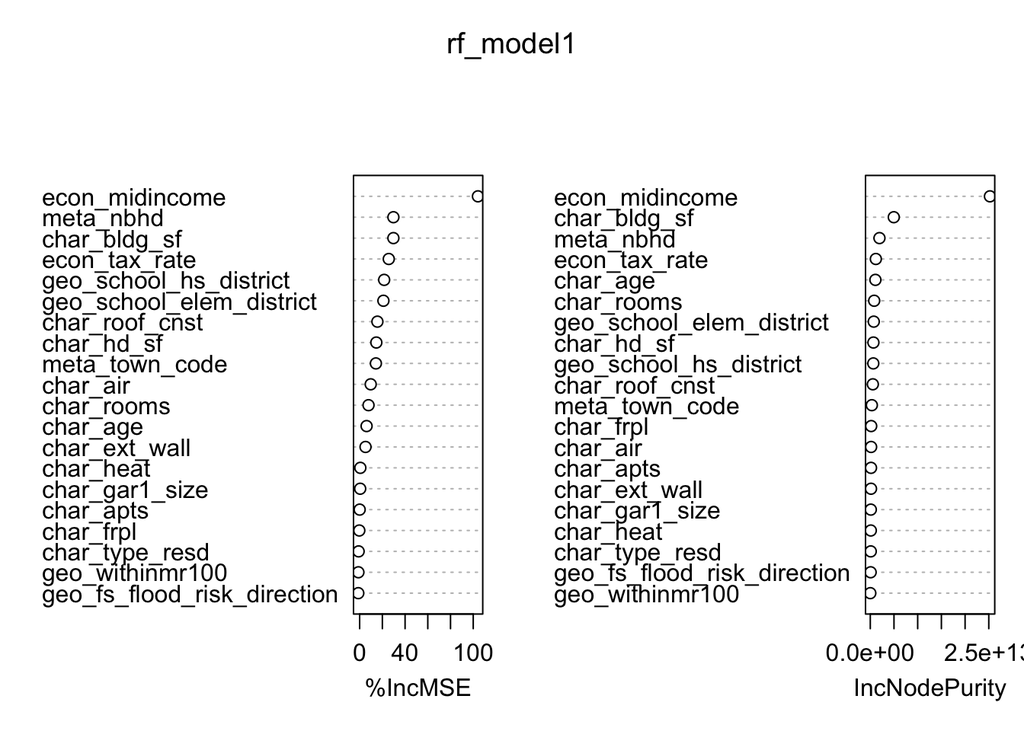

```r
varImpPlot(rf_model1)
```

# Predict Property Assessed Values

### Purpose:

#### The purpose of this script is to predict property assessed values based on a pre-trained random forest model. The script cleans the prediction dataset, handles missing values, applies the trained model to generate predictions, and outputs the results in a structured format for further analysis or reporting. It also provides summary statistics to evaluate the distribution of predicted values.

```r
# Load and Examine New Data
p_data <- read_csv("predict_property_data.csv")
nrow(p_data)
```

```
## [1] 10000
```

```r
head(p_data)
```

```
## # A tibble: 6 × 63
##     pid meta_class meta_town_code meta_nbhd meta_certified_est_bldg
##   <dbl>      <dbl>          <dbl>     <dbl>                   <dbl>
## 1     1        208             26     26010                  434370
## 2     2        211             77     77091                   66430
## 3     3        211             72     72091                   34170
## 4     4        234             32     32160                   97950
## 5     5        234             22     22080                  225820
## 6     6        203             29     29060                  179770
## # ℹ 58 more variables: meta_certified_est_land <dbl>, meta_cdu <chr>,
## #   meta_deed_type <chr>, char_hd_sf <dbl>, char_age <dbl>, char_apts <dbl>,
## #   char_ext_wall <dbl>, char_roof_cnst <dbl>, char_rooms <dbl>,
## #   char_beds <dbl>, char_bsmt <dbl>, char_bsmt_fin <dbl>, char_heat <dbl>,
## #   char_oheat <dbl>, char_air <dbl>, char_frpl <dbl>, char_attic_type <dbl>,
## #   char_fbath <dbl>, char_hbath <dbl>, char_tp_plan <dbl>, char_tp_dsgn <dbl>,
## #   char_cnst_qlty <dbl>, char_site <dbl>, char_gar1_size <dbl>, …
```

```r
colnames(p_data)
```

```
##  [1] "pid"                         "meta_class"
##  [3] "meta_town_code"              "meta_nbhd"
##  [5] "meta_certified_est_bldg"     "meta_certified_est_land"
##  [7] "meta_cdu"                    "meta_deed_type"
##  [9] "char_hd_sf"                  "char_age"
## [11] "char_apts"                   "char_ext_wall"
## [13] "char_roof_cnst"              "char_rooms"
## [15] "char_beds"                   "char_bsmt"
## [17] "char_bsmt_fin"               "char_heat"
## [19] "char_oheat"                  "char_air"
## [21] "char_frpl"                   "char_attic_type"
## [23] "char_fbath"                  "char_hbath"
## [25] "char_tp_plan"                "char_tp_dsgn"
## [27] "char_cnst_qlty"              "char_site"
## [29] "char_gar1_size"              "char_gar1_cnst"
```

[output cut: 17 more lines]

```r
# Fill missing values for categorical and numerical variables
predict_data_clean <- p_data[, important_features]
predict_data_clean[] <- lapply(predict_data_clean, function(x) {
  if(is.factor(x)) {
  # For categorical variables, fill missing values with the most frequent category (mode)
  levels(x)[which.max(table(x))]
  } else {
  # For numerical variables, fill missing values with the median value
  ifelse(is.na(x), median(x, na.rm = TRUE), x)
  }
})

# Use the trained random forest model to make predictions
predicted_values <- predict(rf_model1, newdata = predict_data_clean)

# View the prediction results
head(predicted_values)
```

```
##        1        2        3        4        5        6
## 347402.4 112457.8 109114.3 311557.6 329097.5 322473.5
```

```r
# Combine predictions with the `pid` column from the original data
output <- data.frame(
  pid = p_data$pid, # Extract the property IDs (`pid`)
  assessed_value = predicted_values  # Include the predicted `assessed_value
)

# Round the predicted `assessed_value` to two decimal places for consistency
output$assessed_value <- round(output$assessed_value, 2)


# Preview the final output
head(output)
```

```
##   pid assessed_value
## 1   1       347402.5
## 2   2       112457.8
## 3   3       109114.3
## 4   4       311557.6
## 5   5       329097.5
## 6   6       322473.5
```

```r
# Summarize the predicted values
summary_stats <- summary(output$assessed_value)
summary_stats
```

```
##    Min. 1st Qu.  Median    Mean 3rd Qu.    Max.
##   47914  221049  308657  328825  375068 1679583
```

```r
summary_sd <- sd(output$assessed_value)
cat("Standard Deviation:", summary_sd, "\n")
```

```
## Standard Deviation: 173193.2
```

# Visualize the Distribution of Predicted Assessed Values

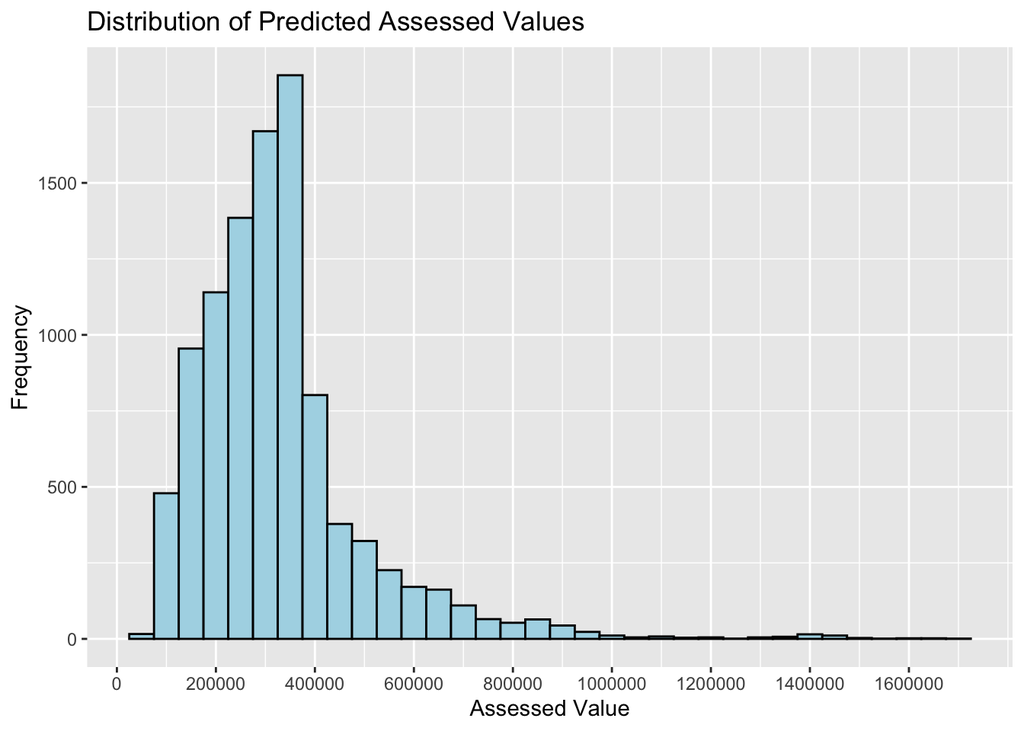

```r
ggplot(output, aes(x = assessed_value)) +
  geom_histogram(binwidth = 50000, fill = "lightblue", color = "black") +
  scale_x_continuous(breaks = seq(0, max(output$assessed_value, na.rm = TRUE), by = 200000)) +
  labs(title = "Distribution of Predicted Assessed Values", x = "Assessed Value", y = "Frequency")
```

# Save the results to a .csv file

```r
write.csv(output, "predicted_assessed_values.csv", row.names = FALSE)
```